# 1. What is Logistic Regression?

Logistic Regression is a Machine Learning algorithm that works on binary classification. So when I say **binary classification**, I mean **only 2 classes should be present in the dependent (target) variable 'y'**.

In Binary Classification, the value of dependent variable (y) is discrete. In other words, the value is in 2 levels (hence binary classification). Hence, the values of x are saturated on either class 0 or class 1, creating a Sigmoid function.

The entire concept of Logistic regression revolves around Odd's ratio. Odd's ratio is the ratio of Prob of Success/Prob of Failure or in other words (P/1-P).

```python
from google.colab import files
from IPython.display import Image
```

```python
uploaded = files.upload()
```

Upload widget is only available when the cell has been executed in the current browser session. Please rerun this cell to enable.

```
Saving Sigmoid_curve.png to Sigmoid_curve (1).png
```

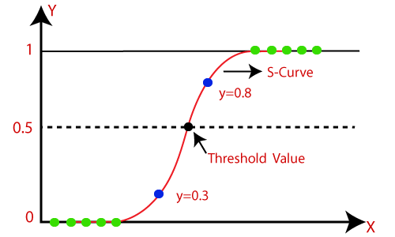

```python
Image('Sigmoid_curve.png')
```

```python
uploaded = files.upload()
```

Upload widget is only available when the cell has been executed in the current browser session. Please rerun this cell to enable.

```
Saving LogicReg_OddsRatio.jpg to LogicReg_OddsRatio.jpg
```

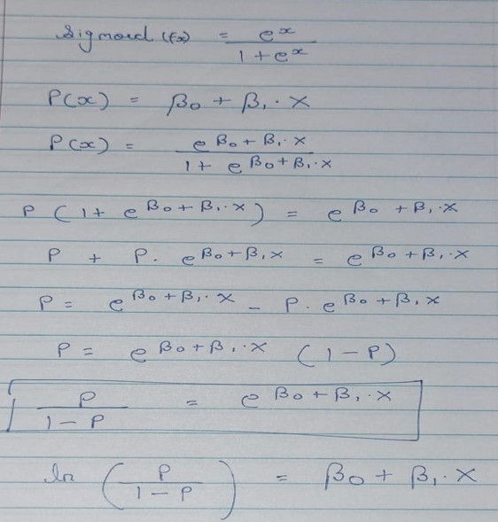

```python
Image('LogicReg_OddsRatio.jpg')
```

# 2. What are the steps involved in Logistic Regression?

The steps used in Logistic Regression are somewhat similar to the one in Linear Regression. The major difference lies in Preprocessing & Evaluating the model. For preprocessing, we are converting categorical columns to numbers and scaling the columns as well (to avoid any bias). In Evaluation, we are using Confusion matrix, accuracy score & recall value to check whether the values are correctly classified.

```python
uploaded = files.upload()
```

Upload widget is only available when the cell has been executed in the current browser session. Please rerun this cell to enable.

```
Saving LogicReg_Steps.jpg to LogicReg_Steps.jpg
```

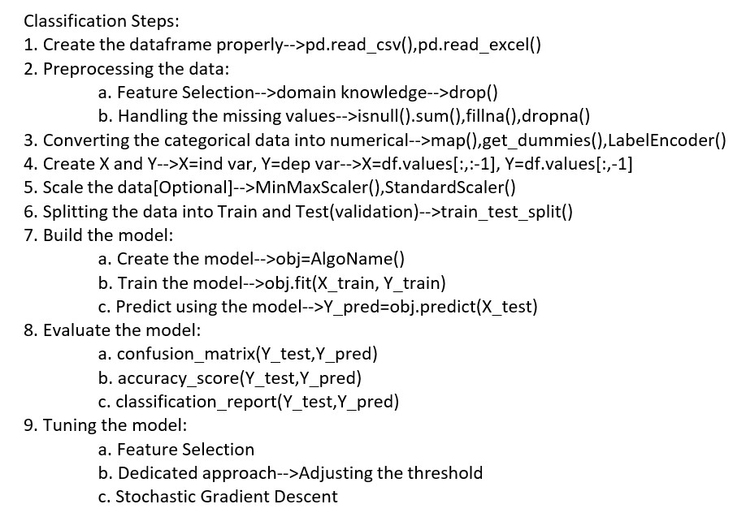

```python
Image('LogicReg_Steps.jpg',width = 800)
```

# 3. What is a Probability matrix?

Probability Matrix works on the concept of Threshold. Say if suppose the value of x is less than the threshold, then it belongs to class 0 if suppose the value of x is more than the threshold, then it belongs to class 1

```python
uploaded = files.upload()
```

Upload widget is only available when the cell has been executed in the current browser session. Please rerun this cell to enable.

```
Saving LogicReg_ProbMatrix.jpg to LogicReg_ProbMatrix.jpg
```

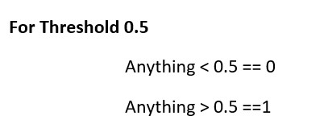

```python
Image('LogicReg_ProbMatrix.jpg',width = 300)
```

# 4. What is a Confusion matrix?

In Machine Learning, not every time the model gives accurate prediction. At times it misplaces values from Class 0 into Class 1 and vice versa. This confusion is then depicted by Confusion matrix as shown below:

```python
uploaded = files.upload()
```

Upload widget is only available when the cell has been executed in the current browser session. Please rerun this cell to enable.

```
Saving LogicReg_ConfusionMatrix.jpg to LogicReg_ConfusionMatrix.jpg
```

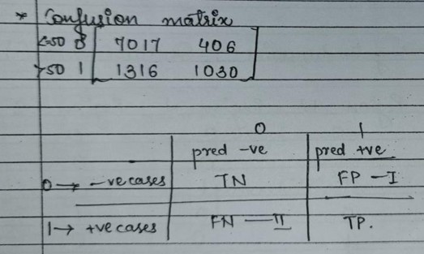

```python
Image('LogicReg_ConfusionMatrix.jpg',width = 500)
```

Let us first understand the terms TN, TP, FN & FP

To understand them first, remember Class 0 ---> -ve & Class 1----> +ve

**TN - True Negative - are the values that belong to negative group (i.e. Class 0).**

**TP - True Positive - are the values that belong to positive group (i.e. Class 1).**

In the example shown above the diagonal values 7017,1030 are TN & TP respectively. They are correctly classified. However the values 1316 & 406 are FN & FP are wrongly classified.

# 5. What is Accuracy score & Recall value?

Logistic Regression Model is evaluated based on Accuracy score & Recall value.

Accuracy score is calculated using ratio of correct predictions to total predictions of the matrix.

***Accuracy score = (TN + TP)/(TN + FN + TP + FP)***

Lower the false predictions, better the accuracy.

Recall Value is the accuracy score of the individual classes.

So, if a particular class has a lower recall value, one can adjust the threshold from probability matrix to fix it.

Recall value for individual classes is given by the formula:

***Recall value for Class 0 – TN/(TN + FP)***

***Recall value for Class 1 – TP/(TP + FN)***

```python
uploaded = files.upload()
```

Upload widget is only available when the cell has been executed in the current browser session. Please rerun this cell to enable.

```
Saving LogicReg_AccuracyScore.jpg to LogicReg_AccuracyScore.jpg
```

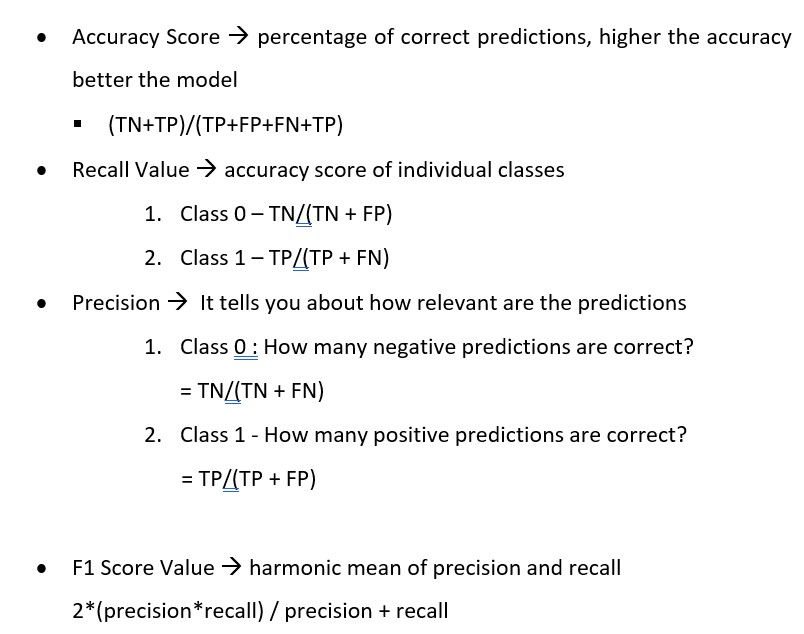

```python
Image('LogicReg_AccuracyScore.jpg', width = 600)
```

# Code

## 1. Importing the libraries & reading the data

```python
#Importing pandas, numpy, matplotib & seaborn libraries and
#assigning them aliases as pd,np, plt & sns

import pandas as pd
import numpy as np
import matplotlib.pyplot as plt
import seaborn as sns
```

```python
# Reading the csv file and storing it in a variable named "data"

data = pd.read_csv("adult_new.csv")
```

```python
data
```

|  | age | workclass | fnlwgt | education | educational-num | marital-status | occupation | relationship | race | gender | capital-gain | capital-loss | hours-per-week | native-country | income |
| --- | --- | --- | --- | --- | --- | --- | --- | --- | --- | --- | --- | --- | --- | --- | --- |
| 0 | 28 | Local-gov | 336951 | Assoc-acdm | 12 | Married-civ-spouse | Protective-serv | Husband | White | Male | 0 | 0 | 40 | United-States | >50K |
| 1 | 44 | Private | 160323 | Some-college | 10 | Married-civ-spouse | Machine-op-inspct | Husband | Black | Male | 7688 | 0 | 40 | United-States | >50K |
| 2 | 63 | Self-emp-not-inc | 104626 | Prof-school | 15 | Married-civ-spouse | Prof-specialty | Husband | White | Male | 3103 | 0 | 32 | United-States | >50K |
| 3 | 65 | Private | 184454 | HS-grad | 9 | Married-civ-spouse | Machine-op-inspct | Husband | White | Male | 6418 | 0 | 40 | United-States | >50K |
| 4 | 48 | Private | 279724 | HS-grad | 9 | Married-civ-spouse | Machine-op-inspct | Husband | White | Male | 3103 | 0 | 48 | United-States | >50K |
| ... | ... | ... | ... | ... | ... | ... | ... | ... | ... | ... | ... | ... | ... | ... | ... |
| 27409 | 27 | Private | 257302 | Assoc-acdm | 12 | Married-civ-spouse | Tech-support | Wife | White | Female | 0 | 0 | 38 | United-States | <=50K |
| 27410 | 40 | Private | 154374 | HS-grad | 9 | Married-civ-spouse | Machine-op-inspct | Husband | White | Male | 0 | 0 | 40 | United-States | >50K |
| 27411 | 58 | Private | 151910 | HS-grad | 9 | Widowed | Adm-clerical | Unmarried | White | Female | 0 | 0 | 40 | United-States | <=50K |
| 27412 | 22 | Private | 201490 | HS-grad | 9 | Never-married | Adm-clerical | Own-child | White | Male | 0 | 0 | 20 | United-States | <=50K |
| 27413 | 52 | Self-emp-inc | 287927 | HS-grad | 9 | Married-civ-spouse | Exec-managerial | Wife | White | Female | 15024 | 0 | 40 | United-States | >50K |

27414 rows × 15 columns

As one can clearly see, here the dependent variable is "income" which is divided into classes >50 K and <= 50 K. So this is an example of Classification and since it has only 2 classes in it, it is called as Binary Classification.

Important thing to remember here is Logistic Regression is used only on Binary classification.

If the Classification is Multi-level, it is not used since the performance is not that good.

## 2. Preprocessing: Check for null values & special characters & treating them (if necessary)

```python
data.isnull().sum()
```

```
age                0
workclass          0
fnlwgt             0
education          0
educational-num    0
marital-status     0
occupation         0
relationship       0
race               0
gender             0
capital-gain       0
capital-loss       0
hours-per-week     0
native-country     0
income             0
dtype: int64
```

So we have got no null values, let us check for special characters then.

```python
for i in data.columns:
    print(f"Unique value for coulmn: {i}\n\n{data[i].unique()}\n")
```

```
Unique value for coulmn: age

[28 44 63 65 48 43 40 34 45 46 36 22 42 41 55 33 59 29 27 31 58 54 37 56
 39 51 50 52 47 24 64 53 35 32 30 68 57 66 49 38 61 73 26 23 25 62 90 60
 67 69 72 85 71 77 70 19 21 74 75 20 81 76 80 88 78 79 84 17 18 82 83 86
 87]

Unique value for coulmn: workclass

['Local-gov' 'Private' 'Self-emp-not-inc' 'State-gov' 'Self-emp-inc' '?'
 'Federal-gov' 'Without-pay' 'Never-worked']

Unique value for coulmn: fnlwgt

[336951 160323 104626 ...  84661 310152 257302]

Unique value for coulmn: education

['Assoc-acdm' 'Some-college' 'Prof-school' 'HS-grad' 'Masters' 'Doctorate'
 'Bachelors' 'Assoc-voc' '9th' '10th' '7th-8th' '11th' '5th-6th' '1st-4th'
 '12th' 'Preschool']

Unique value for coulmn: educational-num

[12 10 15  9 14 16 13 11  5  6  4  7  3  2  8  1]

Unique value for coulmn: marital-status

['Married-civ-spouse' 'Never-married' 'Divorced' 'Separated'
 'Married-AF-spouse' 'Widowed' 'Married-spouse-absent']

Unique value for coulmn: occupation

['Protective-serv' 'Machine-op-inspct' 'Prof-specialty' 'Exec-managerial'
 'Tech-support' 'Craft-repair' 'Sales' 'Other-service' '?'
 'Transport-moving' 'Adm-clerical' 'Handlers-cleaners' 'Farming-fishing'
 'Priv-house-serv' 'Armed-Forces']

Unique value for coulmn: relationship

```

[output cut: 37 more lines]

```
 28 74 73 59 92 69 26 98 97 14 29 22 11 91 81 19 96 88 77 95]

Unique value for coulmn: native-country

['United-States' '?' 'Ireland' 'El-Salvador' 'Japan' 'Poland' 'England'
 'Philippines' 'Germany' 'Thailand' 'Puerto-Rico' 'Portugal' 'China'
 'Canada' 'India' 'Jamaica' 'Honduras' 'South' 'Ecuador' 'Hungary' 'Cuba'
 'Mexico' 'Greece' 'Yugoslavia' 'Dominican-Republic' 'Nicaragua' 'Haiti'
 'Italy' 'Columbia' 'Taiwan' 'Peru' 'France' 'Cambodia'
 'Outlying-US(Guam-USVI-etc)' 'Hong' 'Iran' 'Vietnam' 'Guatemala'
 'Trinadad&Tobago' 'Scotland' 'Laos' 'Holand-Netherlands']

Unique value for coulmn: income

['>50K' '<=50K']
```

We have got some special charcters '?' in the data. Let us replace the special characters with np.nan to make the characters visible. I am storing the substitued data in a new variable 'data_new'

```python
data_new = data.replace("?",np.nan)
```

```python
data_new.isnull().sum()
```

```
age                   0
workclass          1283
fnlwgt                0
education             0
educational-num       0
marital-status        0
occupation         1288
relationship          0
race                  0
gender                0
capital-gain          0
capital-loss          0
hours-per-week        0
native-country      508
income                0
dtype: int64
```

The np.nan have made the characters visible showing 1283 missing values for workclass, 1288 for occupation & 508 for native-country

```python
data_new.shape
```

```
(27414, 15)
```

Null values are treated only if it accounts to less than 30 % of the dataset.

In this case we have max null value % around:

(1288/27414)*100

```python
(1288/27414)*100
```

```
4.6983293207850005
```

Since 4.69 % accounts to less than 30 % of the dataset one can treat the null values with mean/mode/median.

```python
for value in ["workclass","occupation","native-country"]:
    data_new[value].fillna(data_new[value].mode()[0],inplace=True)
```

In the code above, we are using a for loop to sequentially fill up not asssigned (na) values with the first mode of the respective columns. Inplace will update the changes in the dataset without needing it to store in another variable.

```python
data_new.isnull().sum()
```

```
age                0
workclass          0
fnlwgt             0
education          0
educational-num    0
marital-status     0
occupation         0
relationship       0
race               0
gender             0
capital-gain       0
capital-loss       0
hours-per-week     0
native-country     0
income             0
dtype: int64
```

## 3. Preprocessing: Highlighting the Categorical columns and label encoding them

Categorical columns have data in dtype 'object', and before implementing it on ML algorithm it is important that we convert the object dtype into 'int64' (number) by label encoding them.

label encoding basically assigns a number to a string. Before moving on to Label encoding it is essential that we separate the categorical columns first as shown below:

```python
colname=[]
for i in data_new.columns:
    if data_new[i].dtypes== "object":
        colname.append(i)
colname
```

```
['workclass',
 'education',
 'marital-status',
 'occupation',
 'relationship',
 'race',
 'gender',
 'native-country',
 'income']
```

The above loop is used to segregate all the categorical columns from data_new by checking for every column (i) in data_new.columns whether the data type (dtype) of the column is an "object" and appending it to a blank string colname if it's true.

```python
# Label encoding the categorical data

from sklearn.preprocessing import LabelEncoder

le = LabelEncoder()

for x in colname:
    data_new[x]=le.fit_transform(data_new[x])

    le_name_mapping = dict(zip(le.classes_,le.transform(le.classes_)))

    print("Feature",x)
    print("mapping", le_name_mapping)
```

```
Feature workclass
mapping {'Federal-gov': 0, 'Local-gov': 1, 'Never-worked': 2, 'Private': 3, 'Self-emp-inc': 4, 'Self-emp-not-inc': 5, 'State-gov': 6, 'Without-pay': 7}
Feature education
mapping {'10th': 0, '11th': 1, '12th': 2, '1st-4th': 3, '5th-6th': 4, '7th-8th': 5, '9th': 6, 'Assoc-acdm': 7, 'Assoc-voc': 8, 'Bachelors': 9, 'Doctorate': 10, 'HS-grad': 11, 'Masters': 12, 'Preschool': 13, 'Prof-school': 14, 'Some-college': 15}
Feature marital-status
mapping {'Divorced': 0, 'Married-AF-spouse': 1, 'Married-civ-spouse': 2, 'Married-spouse-absent': 3, 'Never-married': 4, 'Separated': 5, 'Widowed': 6}
Feature occupation
mapping {'Adm-clerical': 0, 'Armed-Forces': 1, 'Craft-repair': 2, 'Exec-managerial': 3, 'Farming-fishing': 4, 'Handlers-cleaners': 5, 'Machine-op-inspct': 6, 'Other-service': 7, 'Priv-house-serv': 8, 'Prof-specialty': 9, 'Protective-serv': 10, 'Sales': 11, 'Tech-support': 12, 'Transport-moving': 13}
Feature relationship
mapping {'Husband': 0, 'Not-in-family': 1, 'Other-relative': 2, 'Own-child': 3, 'Unmarried': 4, 'Wife': 5}
Feature race
mapping {'Amer-Indian-Eskimo': 0, 'Asian-Pac-Islander': 1, 'Black': 2, 'Other': 3, 'White': 4}
Feature gender
mapping {'Female': 0, 'Male': 1}
Feature native-country
mapping {'Cambodia': 0, 'Canada': 1, 'China': 2, 'Columbia': 3, 'Cuba': 4, 'Dominican-Republic': 5, 'Ecuador': 6, 'El-Salvador': 7, 'England': 8, 'France': 9, 'Germany': 10, 'Greece': 11, 'Guatemala': 12, 'Haiti': 13, 'Holand-Netherlands': 14, 'Honduras': 15, 'Hong': 16, 'Hungary': 17, 'India': 18, …
Feature income
mapping {'<=50K': 0, '>50K': 1}
```

Label Encoding is done by making use of LabelEncoder function from sklearn library & perpocessing sublibrary.

LableEncoder function is stored in a variable 'le' & later fitted for every column (x) in colname string.

Remember, colname string has the list of all the categorical columns. So, in a way we are applying label encoding using le.fit_transform on all the categorical columns. This will get us the label encoded columns.

To view how this Label encoding has turned out to be, we can use 'dict(zip(le.classes_,le.transform(le.classes_)))', this function makes a dictionary [key:value] to check the class and it's corresponding transformed mapping.

To give an example, look at the mapping done on the native country, mexico is replaced with the number 25. Also, if you look at the mapping for Feature 'income' we got values <=50K: 0, >50K: 1.

To view the mapped columns we can used data_new.head().

```python
data_new.head()
```

|  | age | workclass | fnlwgt | education | educational-num | marital-status | occupation | relationship | race | gender | capital-gain | capital-loss | hours-per-week | native-country | income |
| --- | --- | --- | --- | --- | --- | --- | --- | --- | --- | --- | --- | --- | --- | --- | --- |
| 0 | 28 | 1 | 336951 | 7 | 12 | 2 | 10 | 0 | 4 | 1 | 0 | 0 | 40 | 38 | 1 |
| 1 | 44 | 3 | 160323 | 15 | 10 | 2 | 6 | 0 | 2 | 1 | 7688 | 0 | 40 | 38 | 1 |
| 2 | 63 | 5 | 104626 | 14 | 15 | 2 | 9 | 0 | 4 | 1 | 3103 | 0 | 32 | 38 | 1 |
| 3 | 65 | 3 | 184454 | 11 | 9 | 2 | 6 | 0 | 4 | 1 | 6418 | 0 | 40 | 38 | 1 |
| 4 | 48 | 3 | 279724 | 11 | 9 | 2 | 6 | 0 | 4 | 1 | 3103 | 0 | 48 | 38 | 1 |

## 4. Putting the label encoded values in X and Y

```python
X= data_new.values[:,0:-1]

Y= data_new.values[:,-1]
```

In X we are providing a slicing (range), ':' indicates all rows whereas 0:-1 is the range of column 0 till second last column (column 'age' till 'native country')

In Y we are just providing the index of the last column 'income' hence only -1.

Let us see how X & Y looks like after splitting.

```python
X
```

```
array([[    28,      1, 336951, ...,      0,     40,     38],
       [    44,      3, 160323, ...,      0,     40,     38],
       [    63,      5, 104626, ...,      0,     32,     38],
       ...,
       [    58,      3, 151910, ...,      0,     40,     38],
       [    22,      3, 201490, ...,      0,     20,     38],
       [    52,      4, 287927, ...,      0,     40,     38]], dtype=int64)
```

```python
Y
```

```
array([1, 1, 1, ..., 0, 0, 1], dtype=int64)
```

```python
X.shape
```

```
(27414, 14)
```

```python
Y.shape
```

```
(27414,)
```

## 5. Scaling the high numeric columns from X

High numeric columns are those columns containing too many numbers (e.g. column 'fnlwgt')

Normalization is done using MinMaxScaler() and it divides the values in the range 0 to 1.

Scaling is done using StandardScaler() and it divides all the values in all the columns in the predefined range -3 to 3. It is done for eliminating the bias of the algorithm to a high numeric column. So, in absence of Standard Scaler the Machine Learning algorithm will be biased to a high numeric column.

```python
from sklearn.preprocessing import StandardScaler

scaler=StandardScaler()

scaler.fit(X)
X= scaler.transform(X)
```

```python
print(X)
```

```
[[-0.91080072 -1.82178236  1.41055538 ... -0.24549699 -0.13195044
   0.2536764 ]
 [ 0.30347105 -0.08150981 -0.27597356 ... -0.24549699 -0.13195044
   0.2536764 ]
 [ 1.74541877  1.65876274 -0.80779525 ... -0.24549699 -0.78409618
   0.2536764 ]
 ...
 [ 1.36595884 -0.08150981 -0.35630492 ... -0.24549699 -0.13195044
   0.2536764 ]
 [-1.36615263 -0.08150981  0.11710872 ... -0.24549699 -1.76231478
   0.2536764 ]
 [ 0.91060693  0.78862647  0.94245069 ... -0.24549699 -0.13195044
   0.2536764 ]]
```

In the code above StandardScaler() function from sklearn library and preprocessing sub-library. We are storing this in the variable scaler and one thing to note here is we are scaling only the independent columns and hence we have fit the function on X.

## 6. Performing Train-test split

Similar to Linear Regression we perform Train-test split here as well. This time we have kept test size as 30 % of the data which means the train size would be 70%.

```python
from sklearn.model_selection import train_test_split
X_train,X_test,Y_train,Y_test = train_test_split(X,Y,test_size = 0.3, random_state=10)
```

```python
print(X_train.shape)
print(Y_train.shape)
print()
print(X_test.shape)
print(Y_test.shape)
```

```
(19189, 14)
(19189,)

(8225, 14)
(8225,)
```

## 7. Training the model on LogisticRegression() function

Here we train the model on LogisticRegression() function which we import from sklearn library and linear_model sublibrary. We store the function in a variable called 'classifier' and fit the training data in X & Y on classifier.

```python
from sklearn.linear_model import LogisticRegression

# Create a model object
classifier = LogisticRegression()

# Train the model object
classifier.fit(X_train,Y_train)
```

```
LogisticRegression()
```

## 8. Predicting Y_pred based on X_test data

In the code block below we are performing predictions on the test data and printing the predictions Y_pred.

Also, we are using List with zip to show us the list of predictions that are:

**classified correctly (e.g. (1,1), (0,0))**

**those are wrongly classified (e.g. (1,0),(0,1))**

```python
Y_pred = classifier.predict(X_test)
print(Y_pred)
print(list(zip(Y_test,Y_pred)))
```

```
[1 1 1 ... 1 1 0]
[(1, 1), (1, 1), (1, 1), (1, 0), (1, 1), (1, 1), (0, 1), (0, 0), (1, 1), (1, 1), (1, 1), (0, 0), (0, 0), (0, 0), (0, 0), (0, 0), (0, 0), (1, 0), (1, 1), (0, 1), (0, 0), (0, 0), (0, 0), (0, 0), (0, 1), (1, 0), (0, 0), (1, 1), (1, 1), (0, 1), (0, 0), (0, 0), (0, 0), (1, 1), (1, 0), (0, 0), (1, 1), (1,…
```

## 9. Evaluating the data using Confusion matrix

In the code block below we have imported confusion_matrix, accuracy_score, classification_report from sklearn library & metrics sublibrary.

**Important thing to remember is all these metrics are evaluated on 'Y_test & Y_pred'.**

```python
from sklearn.metrics import confusion_matrix, accuracy_score, classification_report

cfm = confusion_matrix(Y_test, Y_pred)
print(cfm)

print("Classification report: ")

print(classification_report(Y_test,Y_pred))

acc=accuracy_score(Y_test,Y_pred)
print("accuracy of the model:",acc)
```

```
[[3909  798]
 [1096 2422]]
Classification report:
              precision    recall  f1-score   support

           0       0.78      0.83      0.80      4707
           1       0.75      0.69      0.72      3518

    accuracy                           0.77      8225
   macro avg       0.77      0.76      0.76      8225
weighted avg       0.77      0.77      0.77      8225

accuracy of the model: 0.769726443768997
```

So in the confusion matrix generated 3909 values (TN) and 2422 values (TP) are correctly classified, whereas 1096 (FN) and 798 (FP) are the ones wrongly classifed.

Accuracy of the model is 0.7697 or 76.97%.

Recall or so to say individual accuracy of class 0 is 0.83 (83 %) and that of class 1 is 0.69 (69%).

This indicates the performance of class 1 is still poor.

The reason behind this discrepancy can be attributed to the concept of "Class Imbalance". Class Imbalance happens when the value count in each of the class differs making the Ml model favour one class than the other.

let us check the value count of the dependent column y to make it more clear.

```python
data_new['income'].value_counts()
```

```
income
0    15727
1    11687
Name: count, dtype: int64
```

So the above count clearly shows a Class imbalance, where we have got lesser count in Class 1 and hence a lower recall value.

## 10. What are Type 1 & Type 2 errors?

Now that we have learned the algorithm well, the question arrises that whether there's an error which is fatal when it comes to classification. The simple answer is 'yes'.

Type 1 error is the error on whose occurence the purpose of the model is still fulfilled.

Type 2 error is the error on whose occurence the purpose of the model is NOT fulfilled. Type 2 error is fatal when it comes to classification.